# Tidy Tuesday #3

Laith Alayassa

```r
library(tidyverse)     # for graphing and data cleaning
library(lubridate)     # for date manipulation
library(ggthemes)      # for even more plotting themes
theme_set(theme_minimal()) # My favorite ggplot() theme :)
```

```r
# Read in the data for the week

fishing <- readr::read_csv('https://raw.githubusercontent.com/rfordatascience/tidytuesday/master/data/2021/2021-06-08/fishing.csv')
stocked <- readr::read_csv('https://raw.githubusercontent.com/rfordatascience/tidytuesday/master/data/2021/2021-06-08/stocked.csv')
```

Exploring the total amount of fish in lakes by year:

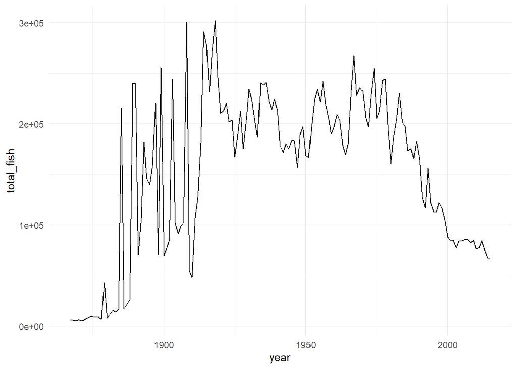

```r
fishing %>%
  group_by(year) %>%
  summarise(total_fish = sum(values , na.rm = TRUE)) %>%
  ggplot(aes(x = year,
             y = total_fish)) +
  geom_line()
```

Then I wanteed to see if this distribution from the previous graph follows for all lakes or if there are different or odd patterns:

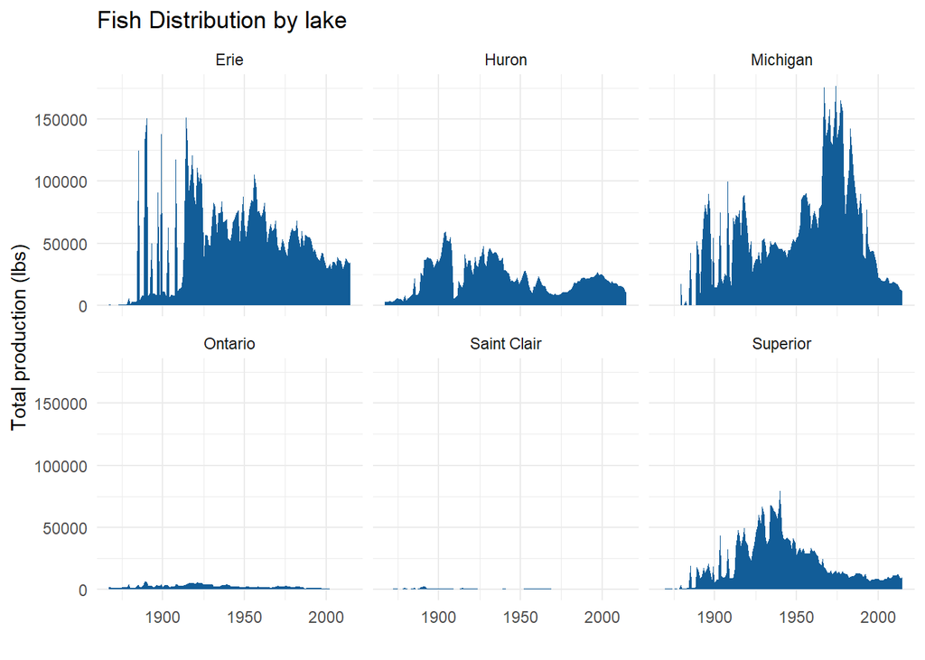

```r
fishing %>%
  group_by(year, lake) %>%
  summarise(total_fish = sum(values , na.rm = TRUE)) %>%
  ggplot(aes(x = year,
             y = total_fish)) +
  geom_area(fill = '#125d98') +
  facet_wrap(vars(lake)) +
  labs(title = "Fish Distribution by lake",
       x = "",
       y = "Total production (lbs)") +
  theme(legend.position = 'none')
```

I immediately notice that there are different patterns, especially with Lake Michigan which is the only one that seems to have increasing numbers around the 70’s, unlike other lakes that seem to have decreasing numbers, however, to better see the patterns I think it would be a good idea to free the y-axis since I am more intereseted in the trend and not the actual numbers:

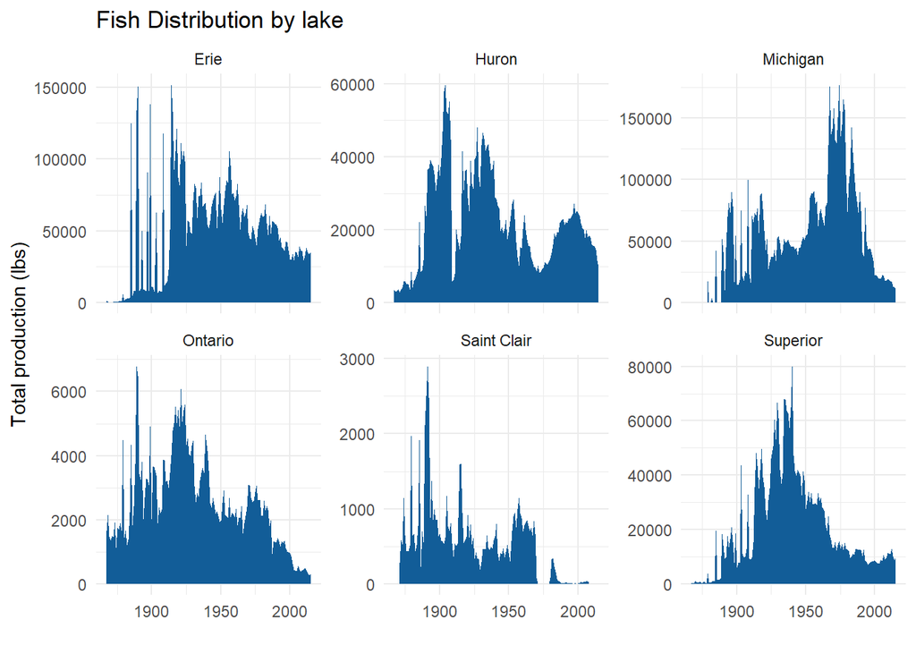

```r
fishing %>%
  group_by(year, lake) %>%
  summarise(total_fish = sum(values , na.rm = TRUE)) %>%
  ggplot(aes(x = year,
             y = total_fish)) +
  geom_area(fill = '#125d98') +
  facet_wrap(vars(lake), scales = "free_y") +
  labs(title = "Fish Distribution by lake",
       x = "",
       y = "Total production (lbs)") +
  theme(legend.position = 'none')
```

To explore that seeminglt odd increase in lake Michigan, I want to look at how different species of fish changed population:

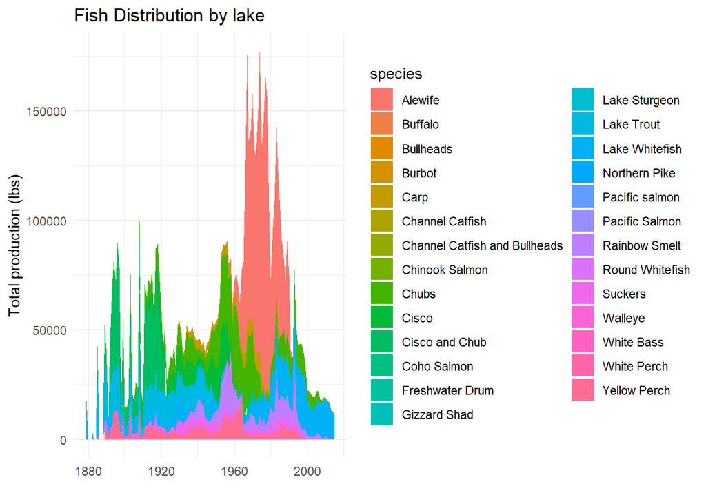

```r
fishing %>%
  filter(lake == "Michigan") %>%
  group_by(year, species) %>%
  summarise(total_values = sum(values, na.rm = TRUE)) %>%
  ggplot(aes(x = year,
             y = total_values)) +
  geom_area(aes(fill = species))+
  labs(title = "Fish Distribution by lake",
       x = "",
       y = "Total production (lbs)")
```

Altohugh this is not the easiest to read, but we are fortunate to easily find the the only spiking species causing all the increase for this lake is Alewife. To better understand its effect I will try to combine all species except for Alewife and see if there is a pattern:

```r
fishing_lumped <- fishing %>%
  filter(lake == "Michigan") %>%
  group_by(species) %>%
  summarise(total_weight = sum(values, na.rm = TRUE)) %>%
  mutate(fish_grp = fct_lump(species, n = 1, w = total_weight))
```

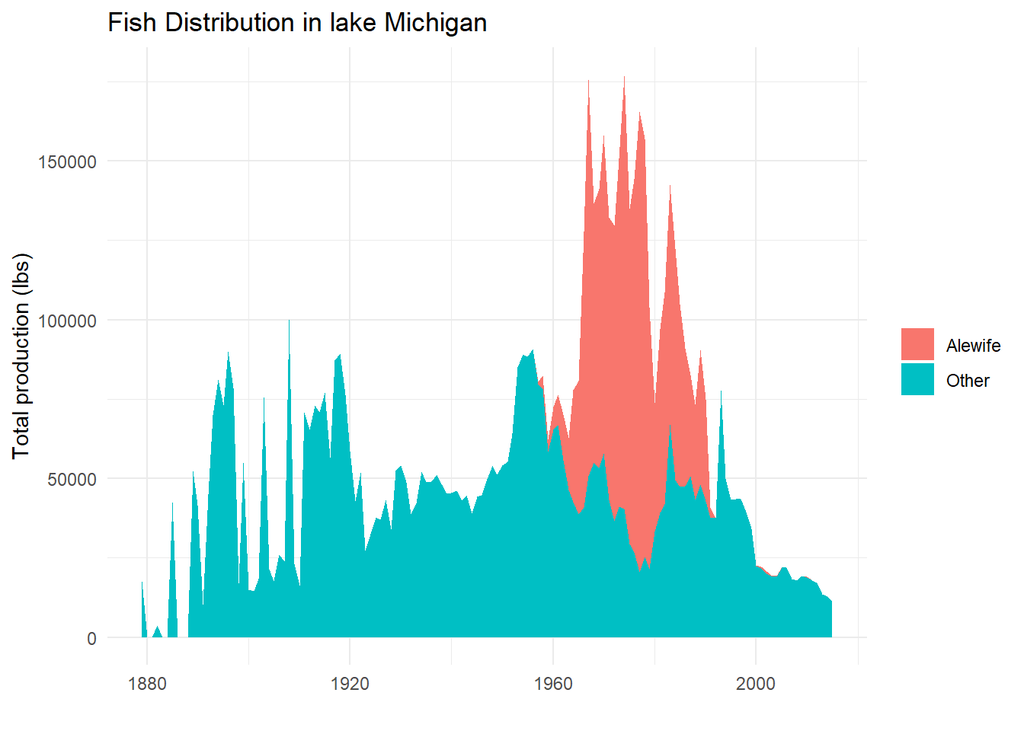

```r
fishing %>%
  inner_join(fishing_lumped, by = "species") %>%
  filter(lake == "Michigan") %>%
  group_by(year, fish_grp) %>%
  summarise(total_values = sum(values, na.rm = TRUE)) %>%
  ggplot(aes(x = year,
             y = total_values)) +
  geom_area(aes(fill = fish_grp))+
  labs(title = "Fish Distribution in lake Michigan",
       x = "",
       y = "Total production (lbs)") +
  theme(legend.title = element_blank())
```

We can see the the increase in lake michigan that we noticed was nearly entirely caused by the increase in the numbers of Alewife species, at the same time, we see a decrease in the numbers of all other species suggesting imbalance in the eco system. To see the number if Alewife before the spike I will change the geom to something more readable:

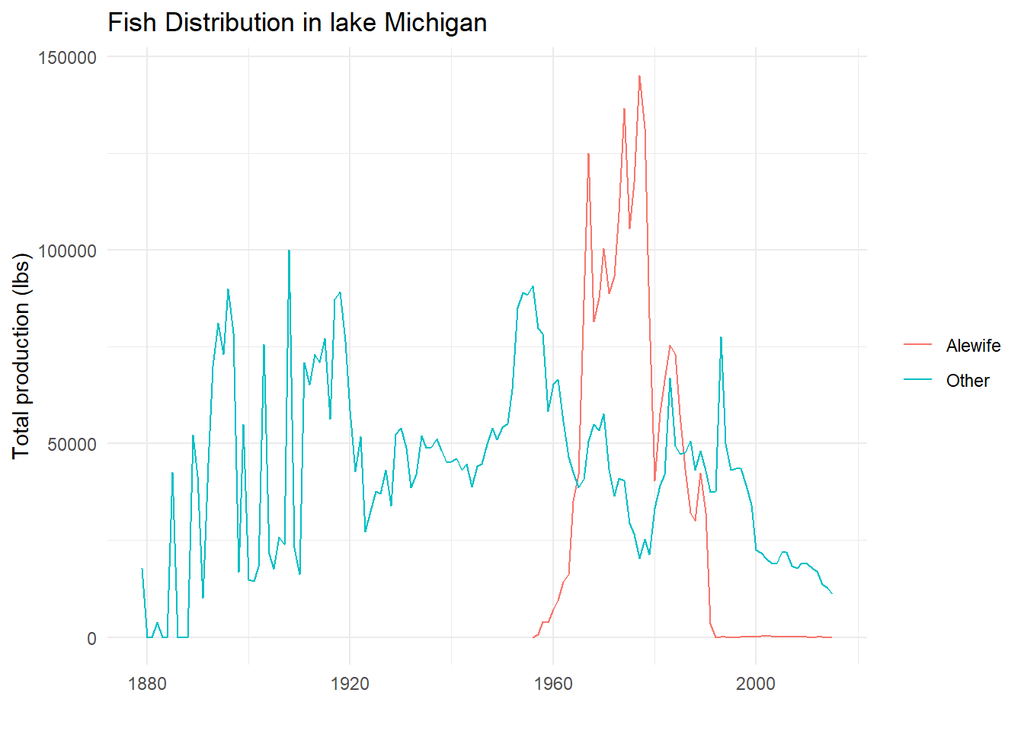

```r
fishing %>%
  inner_join(fishing_lumped, by = "species") %>%
  filter(lake == "Michigan") %>%
  group_by(year, fish_grp) %>%
  summarise(total_values = sum(values, na.rm = TRUE)) %>%
  ggplot(aes(x = year,
             y = total_values)) +
  geom_line(aes(color = fish_grp))+
  labs(title = "Fish Distribution in lake Michigan",
       x = "",
       y = "Total production (lbs)") +
  theme(legend.title = element_blank())
```

We see that the Alewife was not native to this lake and was only came before the 1960’s, and we can see a corresponding decrease in the numbers of all other species when it came. However, this graph doesn’t explain the continuing decrease in numbers of all species after the decline of Alewife numbers.